# Assignment 13: Text Mining

*How to do it?*:

- Open the Rmarkdown file of this assignment (link) in Rstudio.
- Right under each **question**, insert a code chunk (you can use the hotkey `Ctrl + Alt + I` to add a code chunk) and code the solution for the question.
- `Knit` the rmarkdown file (hotkey: `Ctrl + Alt + K`) to export an html.
- Publish the html file to your Githiub Page.

*Submission*: Submit the link on Github of the assignment to Canvas

Sample Codes

### Netflix Data

**1.** Download the `netflix_titles` at this link. Create a century variable taking two values:

```
- '21' if the released_year is greater or equal to 2000, and

- '20' otherwise.
```

```r
library(tidyverse)
library(dplyr)
library(tidytext)
library(knitr)
df <- read_csv('netflix_titles.csv')

head(df)
```

```
## # A tibble: 6 × 12
##   show_id type    title director    cast  country date_…¹ relea…² rating durat…³
##   <chr>   <chr>   <chr> <chr>       <chr> <chr>   <chr>     <dbl> <chr>  <chr>
## 1 s1      TV Show 3%    <NA>        João… Brazil  August…    2020 TV-MA  4 Seas…
## 2 s2      Movie   7:19  Jorge Mich… Demi… Mexico  Decemb…    2016 TV-MA  93 min
## 3 s3      Movie   23:59 Gilbert Ch… Tedd… Singap… Decemb…    2011 R      78 min
## 4 s4      Movie   9     Shane Acker Elij… United… Novemb…    2009 PG-13  80 min
## 5 s5      Movie   21    Robert Luk… Jim … United… Januar…    2008 PG-13  123 min
## 6 s6      TV Show 46    Serdar Akar Erda… Turkey  July 1…    2016 TV-MA  1 Seas…
## # … with 2 more variables: listed_in <chr>, description <chr>, and abbreviated
## #   variable names ¹date_added, ²release_year, ³duration
```

```r
df$century <- case_when(df$release_year >= 2000 ~ '21',
                       TRUE ~ '20')
```

**2. Word Frequency**

1. Convert the description to tokens, remove all the stop words. What are the top 10 frequent words of movies/TV Shows in the 20th century. Plot the bar chart of the frequency of these words.

```r
df %>% select(title, description) %>%
  unnest_tokens(input = description, output = word) %>%
  anti_join(get_stopwords()) %>%
  head(20)
```

```
## # A tibble: 20 × 2
##    title word
##    <chr> <chr>
##  1 3%    future
##  2 3%    elite
##  3 3%    inhabit
##  4 3%    island
##  5 3%    paradise
##  6 3%    far
##  7 3%    crowded
##  8 3%    slums
##  9 3%    get
## 10 3%    one
## 11 3%    chance
## 12 3%    join
## 13 3%    3
## 14 3%    saved
## 15 3%    squalor
## 16 7:19  devastating
## 17 7:19  earthquake
## 18 7:19  hits
## 19 7:19  mexico
## 20 7:19  city
```

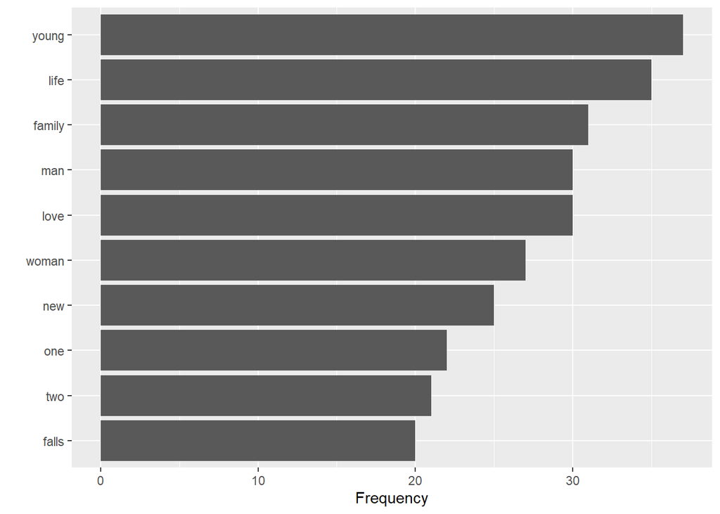

```r
df %>%
  filter(century=='20') %>%
  unnest_tokens(input = description, output = word) %>%
  anti_join(get_stopwords()) %>%
  count(type, word, sort = TRUE) %>%
  head(10) %>%
  ggplot(aes(x = n, y = reorder(word, n))) +
  geom_col() +
  labs(y = '', x = 'Frequency')
```

2. What are the top 10 frequent words of movies/TV Shows in the 21st century. Plot the bar chart of the frequency of these words. Plot a side-by-side bar charts to compare the most frequent words by the two centuries.

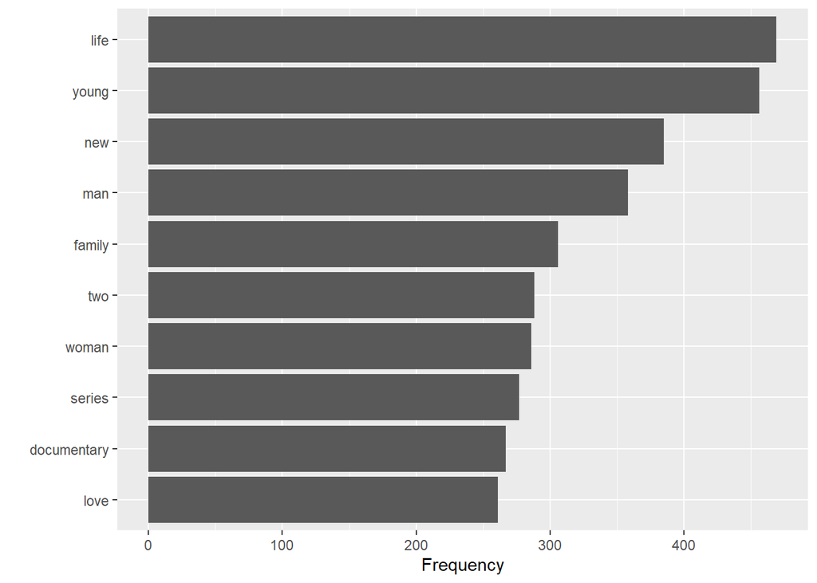

```r
df %>%
  filter(century=='21') %>%
  unnest_tokens(input = description, output = word) %>%
  anti_join(get_stopwords()) %>%
  count(type, word, sort = TRUE) %>%
  head(10) %>%
  ggplot(aes(x = n, y = reorder(word, n))) +
  geom_col() +
  labs(y = '', x = 'Frequency')
```

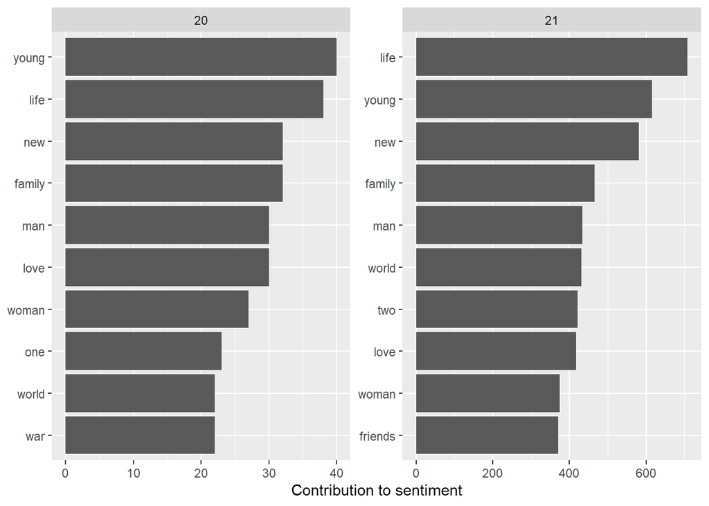

```r
df %>%
  unnest_tokens(input = description, output = word) %>%
  anti_join(get_stopwords()) %>%
  count(century, word, sort = TRUE) %>%
  group_by(century) %>%
  slice_max(n, n = 10) %>%
  ungroup() %>%
  mutate(word = reorder_within(word, by = n, within = century)) %>%
  ggplot(aes(n, word)) +
  geom_col(show.legend = FALSE) +
  facet_wrap(~century, scales = "free") +
  labs(x = "Contribution to sentiment",
       y = NULL)+
  scale_y_reordered()
```

**3. Word Cloud**

1. Plot the word cloud of the words in the descriptions in the movies/TV Shows in the 20th century.

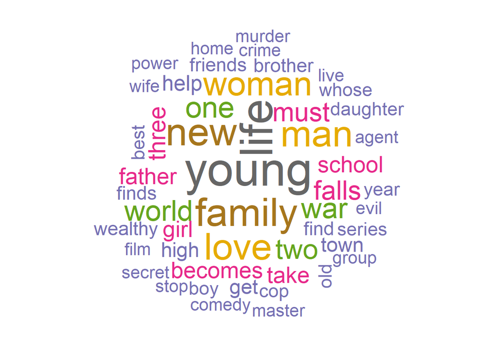

```r
library(wordcloud)
pal <- brewer.pal(8,"Dark2")

df %>%
  filter(century=='20') %>%
  unnest_tokens(input = description, output = word) %>%
  anti_join(get_stopwords()) %>%
  count(word, sort = TRUE) %>%
  with(wordcloud(word, n, random.order = FALSE, max.words = 50, colors=pal))
```

2. Plot the word cloud of the words in the descriptions in the movies/TV Shows in the 21st century.

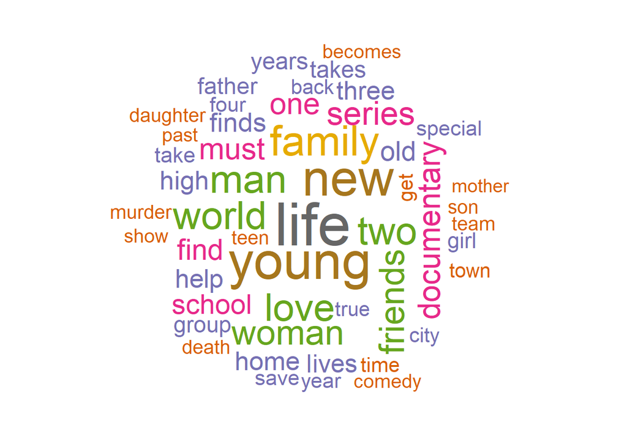

```r
df %>%
  filter(century=='21') %>%
  unnest_tokens(input = description, output = word) %>%
  anti_join(get_stopwords()) %>%
  count(word, sort = TRUE) %>%
  with(wordcloud(word, n, random.order = FALSE, max.words = 50, colors=pal))
```

**4. Sentiment Analysis**

1. Is movies/TV Shows in the 21st century tends to be more positive than those in 20th century? Use the sentiment analysis by `Bing` lexicons to address the question.

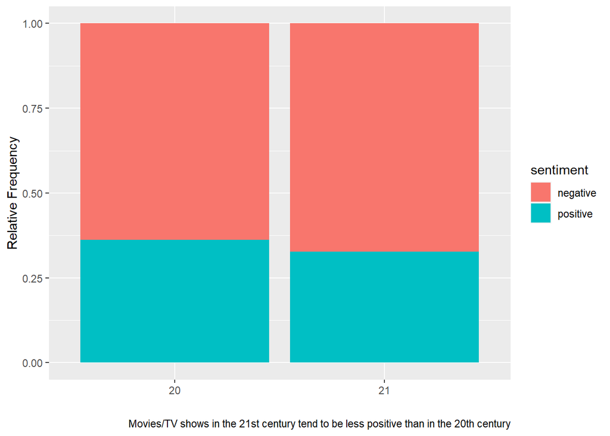

```r
df %>%
    unnest_tokens(input = description, output = word) %>%
    anti_join(get_stopwords()) %>%
    count(century, word, sort = TRUE) %>%
    group_by(century) %>%
    inner_join(get_sentiments("bing")) %>%
    filter(!is.na(sentiment)) %>%
    count(sentiment, sort = TRUE) %>%
    group_by(century) %>%
    mutate(n = n/sum(n)) %>%
    ggplot(aes(century, n, fill=sentiment))+geom_col(position = 'fill')+
    labs(y='Relative Frequency', x ='',caption='Movies/TV shows in the 21st century tend to be less positive than in the 20th century')
```

2. Do sentiment analysis using `nrc` and `afinn` lexicons. Give your comments on the results.

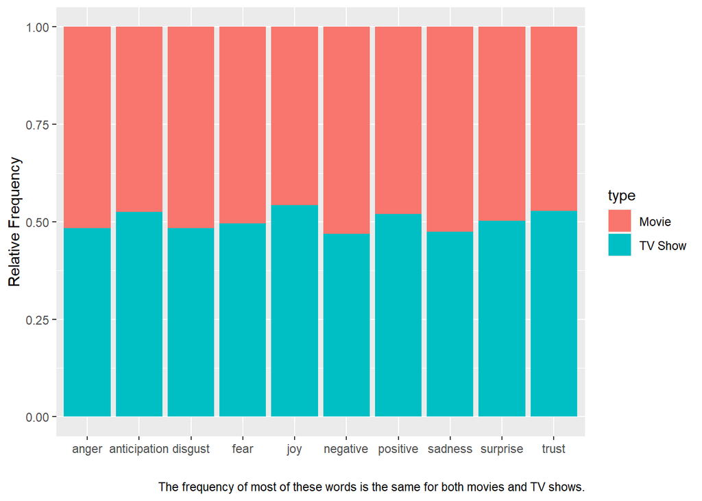

```r
df %>%
    unnest_tokens(input = description, output = word) %>%
    anti_join(get_stopwords()) %>%
    count(type, word, sort = TRUE) %>%
    group_by(type) %>%
    inner_join(get_sentiments("nrc")) %>%
    filter(!is.na(sentiment)) %>%
    count(sentiment, sort = TRUE) %>%
    group_by(type) %>%
    mutate(n = n/sum(n)) %>%
    ggplot(aes(sentiment, n, fill=type))+geom_col(position = 'fill')+
    labs(y='Relative Frequency', x ='', caption='The frequency of most of these words is the same for both movies and TV shows.')
```

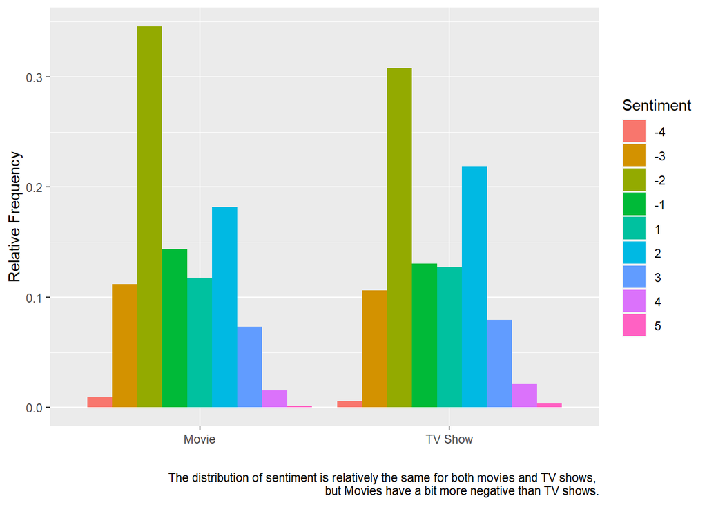

```r
df %>%
    unnest_tokens(input = description, output = word) %>%
    anti_join(get_stopwords()) %>%
    count(type, word, sort = TRUE) %>%
    group_by(type) %>%
    inner_join(get_sentiments("afinn")) %>%
    mutate(sentiment = value) %>%
    filter(!is.na(sentiment)) %>%
    count(sentiment, sort = TRUE) %>%
    group_by(type) %>%
    mutate(n = n/sum(n)) %>%
    ggplot(aes(type, n, fill=factor(sentiment)))+geom_col(position = 'dodge')+
    labs(y='Relative Frequency', fill = 'Sentiment', x = '', caption='The distribution of sentiment is relatively the same for both movies and TV shows,
         but Movies have a bit more negative than TV shows.')
```

**5. Modeling**

1. Use the description to predict if a movie/TV show is in 20th or 21st century. Give the accuracy and plot the confusion matrix table.

```r
library(caret)
library(themis)
library(textrecipes)
# Select data and set target
df1 <- df %>%
  select(century, description) %>%
  mutate(target = century)
```

```r
# Convert text data to numeric variables
a <- recipe(target~description,
       data = df1) %>%
  step_tokenize(description) %>%
  step_tokenfilter(description, max_tokens = 50) %>%
  step_tfidf(description) %>%
  step_normalize(all_numeric_predictors()) %>%
  step_smote(target) %>%
  prep()
df1 <- juice(a)
```

```r
# Using Caret for modeling
set.seed(2021)
splitIndex <- createDataPartition(df1$target, p = .7,
                                  list = FALSE)
df_train <- df1[ splitIndex,]
df_test <- df1[-splitIndex,]

forest_ranger <- train(target~., data=df_train,
                        method = "ranger")

pred <- predict(forest_ranger, df_test)

cm <- confusionMatrix(data = pred, reference = df_test$target)
cm$overall[1]
```

```
##  Accuracy
## 0.9811449
```

```r
d = data.frame(pred = pred, obs = df_test$target)

library(yardstick)
```

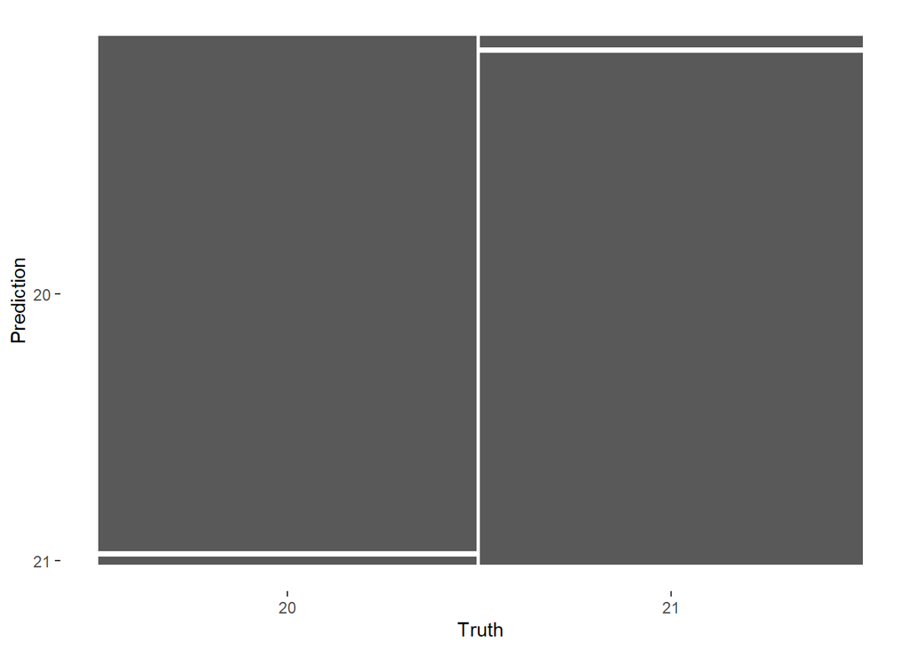

```r
d %>% conf_mat(pred, obs) %>% autoplot
```

2. Create variable century2 taking three following values. (Hint: You can use the case_when function to do this)

```
- `21` if released_year is greater or equal to 2000

- `second_half_20`if released_year is greater than or equal to 1950 and less than 2000

- `first_half_20` otherwise
```

```r
df$century2 <- case_when(df$release_year >= 2000 ~ '21',
                         df$release_year >= 1950 ~ 'second_half_20',
                         TRUE ~ 'first_half_20')
```

Predict century2 using the descriptions. Give the accuracy and plot the confusion matrix table. (Notice that the codes for 8 should still work for this question)

```r
# Select data and set target
df2 <- df %>%
  select(century2, description) %>%
  mutate(target = century2)
```

```r
# Convert text data to numeric variables
a <- recipe(target~description,
       data = df2) %>%
  step_tokenize(description) %>%
  step_tokenfilter(description, max_tokens = 50) %>%
  step_tfidf(description) %>%
  step_normalize(all_numeric_predictors()) %>%
  step_smote(target) %>%
  prep()
df2 <- juice(a)
```

```r
# Using Caret for modeling
set.seed(2021)
splitIndex <- createDataPartition(df2$target, p = .7,
                                  list = FALSE)
df_train <- df2[ splitIndex,]
df_test <- df2[-splitIndex,]

forest_ranger <- train(target~., data=df_train,
                        method = "ranger")

pred <- predict(forest_ranger, df_test)

cm <- confusionMatrix(data = pred, reference = df_test$target)
cm$overall[1]
```

```
##  Accuracy
## 0.9877328
```

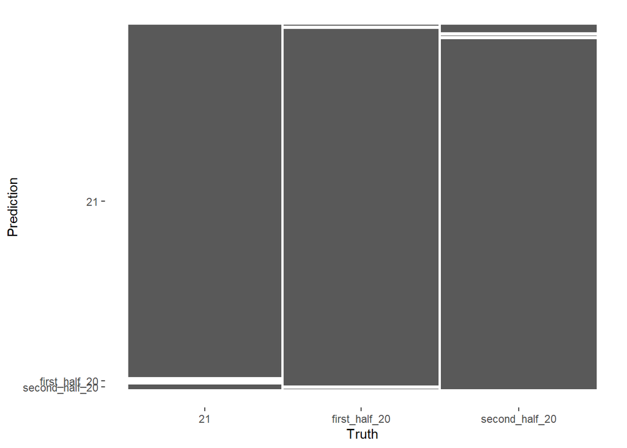

```r
d = data.frame(pred = pred, obs = df_test$target)

library(yardstick)

d %>% conf_mat(pred, obs) %>% autoplot
```

**6.** Create another categorical variable from the data and do the following

```r
df$newness <- case_when(df$release_year >= 2020 ~ 'New',
                         df$release_year >= 2017 ~ 'Old',
                         TRUE ~ 'Very Old')
```

```
- Plot side-by-side word frequency by different categories of the newly created variable
```

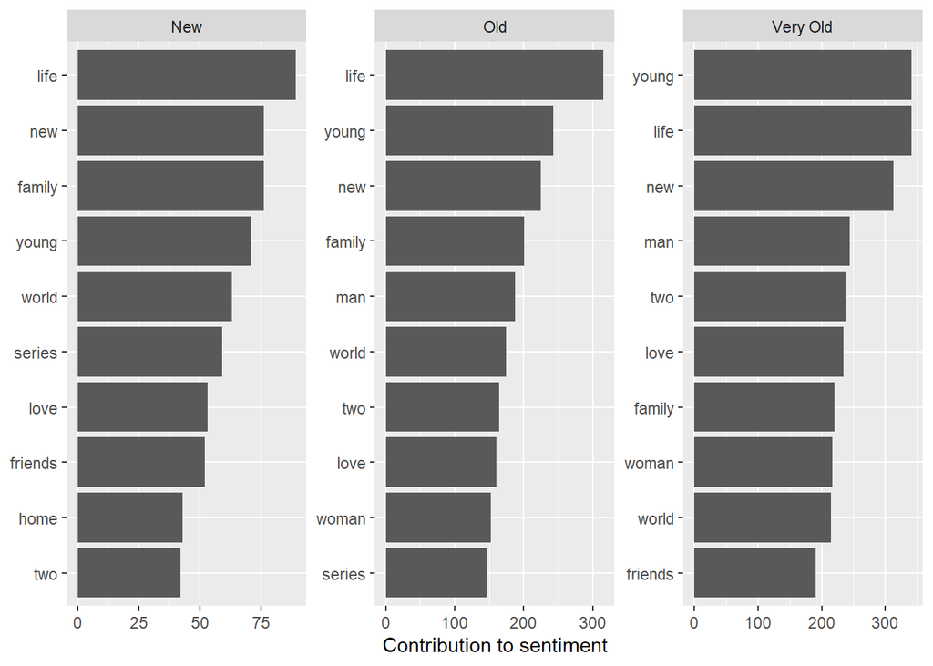

```
- Plot word clouds on different categories of the newly created variable
```

```r
df %>%
  unnest_tokens(input = description, output = word) %>%
  anti_join(get_stopwords()) %>%
  count(newness, word, sort = TRUE) %>%
  group_by(newness) %>%
  slice_max(n, n = 10) %>%
  ungroup() %>%
  mutate(word = reorder_within(word, by = n, within = newness)) %>%
  ggplot(aes(n, word)) +
  geom_col(show.legend = FALSE) +
  facet_wrap(~newness, scales = "free") +
  labs(x = "Contribution to sentiment",
       y = NULL)+
  scale_y_reordered()
```

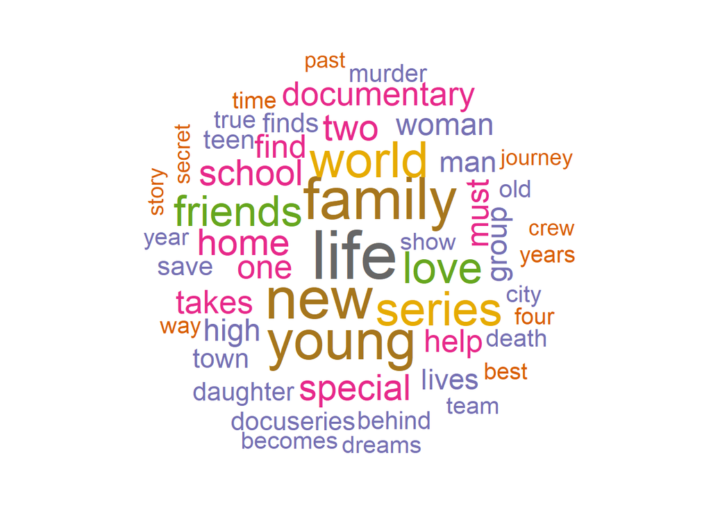

```r
pal <- brewer.pal(8,"Dark2")

df %>%
  filter(newness=='New') %>%
  unnest_tokens(input = description, output = word) %>%
  anti_join(get_stopwords()) %>%
  count(word, sort = TRUE) %>%
  with(wordcloud(word, n, random.order = FALSE, max.words = 50, colors=pal))
```

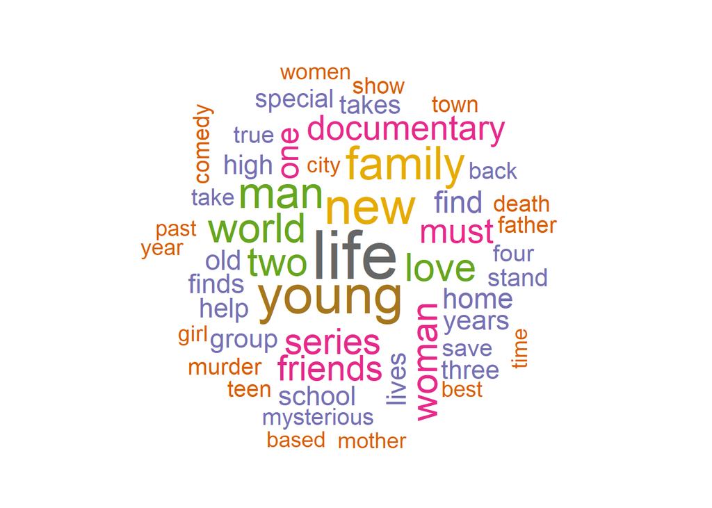

```r
pal <- brewer.pal(8,"Dark2")

df %>%
  filter(newness=='Old') %>%
  unnest_tokens(input = description, output = word) %>%
  anti_join(get_stopwords()) %>%
  count(word, sort = TRUE) %>%
  with(wordcloud(word, n, random.order = FALSE, max.words = 50, colors=pal))
```

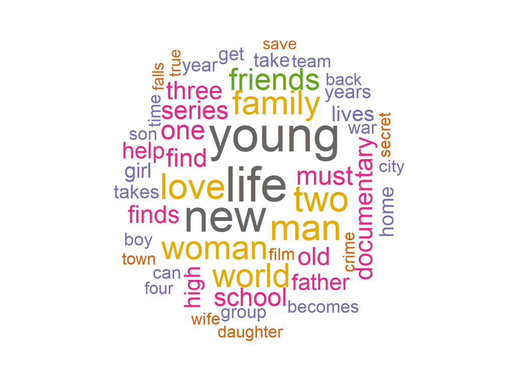

```
- Do sentiment analysis to compare different categories of the newly created variable
```

```r
pal <- brewer.pal(8,"Dark2")

df %>%
  filter(newness=='Very Old') %>%
  unnest_tokens(input = description, output = word) %>%
  anti_join(get_stopwords()) %>%
  count(word, sort = TRUE) %>%
  with(wordcloud(word, n, random.order = FALSE, max.words = 50, colors=pal))
```

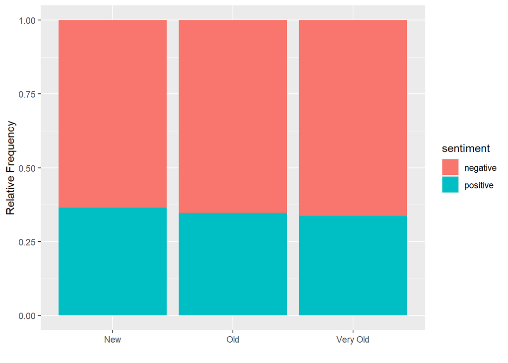

```
- Predict the newly created variable using the description. Give the accuracy and plot the confusion matrix table.
```

```r
df %>%
    unnest_tokens(input = description, output = word) %>%
    anti_join(get_stopwords()) %>%
    count(newness, word, sort = TRUE) %>%
    group_by(newness) %>%
    inner_join(get_sentiments("bing")) %>%
    filter(!is.na(sentiment)) %>%
    count(sentiment, sort = TRUE) %>%
    group_by(newness) %>%
    mutate(n = n/sum(n)) %>%
    ggplot(aes(newness, n, fill=sentiment))+geom_col(position = 'fill')+
    labs(y='Relative Frequency', x ='')
```

```r
# Select data and set target
df3 <- df %>%
  select(newness, description) %>%
  mutate(target = newness)
```

```r
# Convert text data to numeric variables
a <- recipe(target~description,
       data = df3) %>%
  step_tokenize(description) %>%
  step_tokenfilter(description, max_tokens = 50) %>%
  step_tfidf(description) %>%
  step_normalize(all_numeric_predictors()) %>%
  step_smote(target) %>%
  prep()
df3 <- juice(a)
```

```r
# Using Caret for modeling
set.seed(2021)
splitIndex <- createDataPartition(df3$target, p = .7,
                                  list = FALSE)
df_train <- df3[ splitIndex,]
df_test <- df3[-splitIndex,]

forest_ranger <- train(target~., data=df_train,
                        method = "ranger")

pred <- predict(forest_ranger, df_test)

cm <- confusionMatrix(data = pred, reference = df_test$target)
cm$overall[1]
```

```
##  Accuracy
## 0.6474416
```

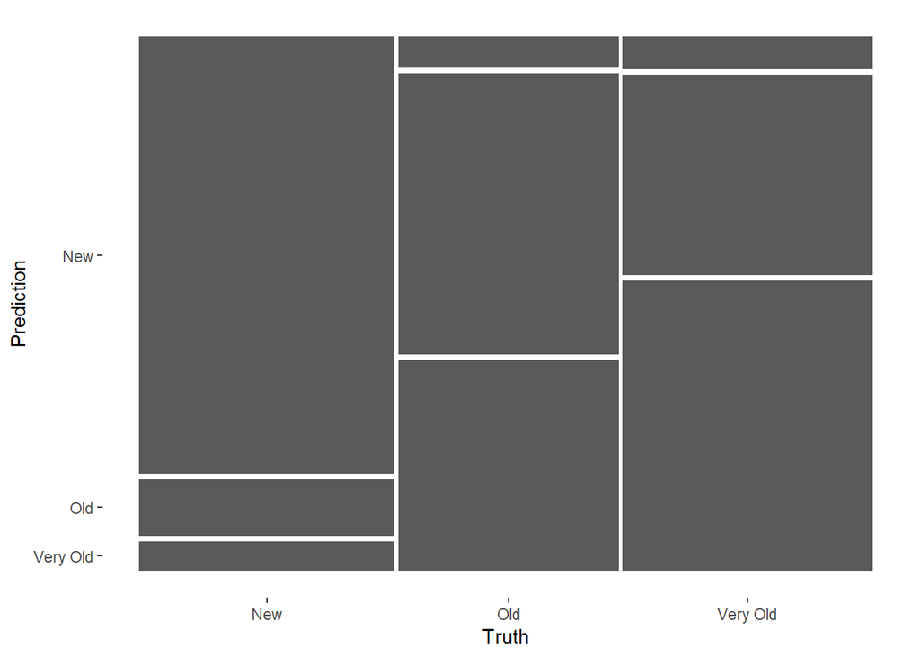

```r
d = data.frame(pred = pred, obs = df_test$target)

library(yardstick)

d %>% conf_mat(pred, obs) %>% autoplot
```